# El t-test paso a paso: de Student a R

Curso: Introducción a programación y análisis de datos en R

Autor/a

Afiliación

Filip Andras

CIMCYC — Universidad de Granada

Fecha de publicación

15 octubre 2026

# Contexto histórico: William Sealy Gosset

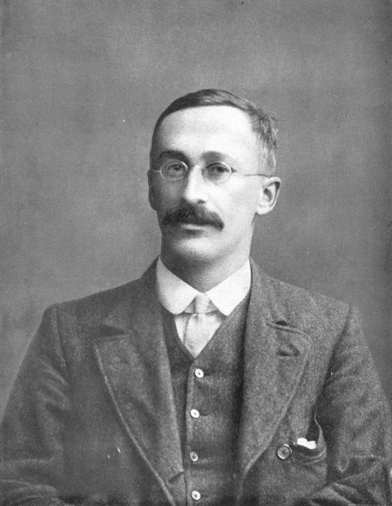

William Sealy Gosset  
(1876-1937)

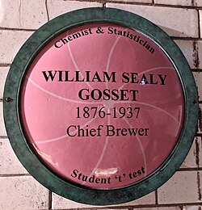

Placa conmemorativa

En 1908, un químico de la cervecera **Guinness** en Dublin publicó uno de los articulos más influyentes de la estadística moderna. Su nombre era **William Sealy Gosset** (1876-1937), pero publicó bajo el pseudónimo **“Student”** porque Guinness no permitía a sus empleados publicar con su nombre real.

El problema de Gosset era práctico: necesitaba comparar la calidad de ingredientes (cebada, lúpulo) con **muestras muy pequeñas** (n = 3-10). Las herramientas estadísticas de la época asumían muestras grandes. Gosset desarrolló una distribución que funcionaba con muestras pequeñas: la **distribución t de Student**.

**NotaDato curioso**

Gosset trabajó toda su vida en Guinness. La cervecera tenía una política de secreto industrial tan estricta que el pseudónimo “Student” fue necesario para poder publicar. Su artículo de 1908, *The probable error of a mean*, es uno de los más citados en la historia de la estadística.

# El marco NHST (Null Hypothesis Significance Testing)

## La lógica del contraste de hipótesis

1. Planteamos dos hipótesis: **H<sub>0</sub>** (no hay efecto) y **H<sub>1</sub>** (sí hay efecto)
2. Calculamos un **estadístico** (como t o F) a partir de los datos
3. Calculamos el **p-valor**: la probabilidad de obtener un resultado tan extremo o más **si H<sub>0</sub> fuera cierta**
4. Si p < $\alpha$ (normalmente 0.05), **rechazamos H<sub>0</sub>**

## Errores de tipo I y tipo II

|  | H<sub>0</sub> es verdadera | H<sub>0</sub> es falsa |
| --- | --- | --- |
| **No rechazamos H<sub>0</sub>** | Correcto | Error tipo II ($\beta$) |
| **Rechazamos H<sub>0</sub>** | Error tipo I ($\alpha$) | Correcto (potencia = 1 - $\beta$) |

- **Error tipo I** ($\alpha$): decir que hay efecto cuando no lo hay (falso positivo)
- **Error tipo II** ($\beta$): no detectar un efecto que existe (falso negativo)
- **Potencia**: probabilidad de detectar un efecto real

**NotaEl marco frecuentista**

El NHST se basa en la estadística **frecuentista**: las probabilidades se interpretan como frecuencias a largo plazo. El $\alpha$ = 0.05 significa que, si repitiéramos el experimento muchas veces **cuando H<sub>0</sub> es cierta**, rechazaríamos H<sub>0</sub> incorrectamente solo el 5% de las veces.

# La distribución t de Student

La distribución t es similar a la normal, pero con **colas más pesadas**. Con muestras pequeñas, hay más incertidumbre, y las colas capturan esa incertidumbre. ([Formulación matemática en Wikipedia](https://en.wikipedia.org/wiki/Student%27s_t-distribution))

## ¿De qué depende?

La distribución t depende de un solo parámetro: los **grados de libertad** (df = *degrees of freedom*).

- Para un t-test de muestras independientes: $df = n_A + n_B - 2$
- Más observaciones → más df → la distribución se parece más a la normal
- Con pocas observaciones (df bajo), las colas son más anchas → necesitamos un valor t más extremo para rechazar H<sub>0</sub>

A medida que df aumenta, la t se aproxima a la normal:

**Código**

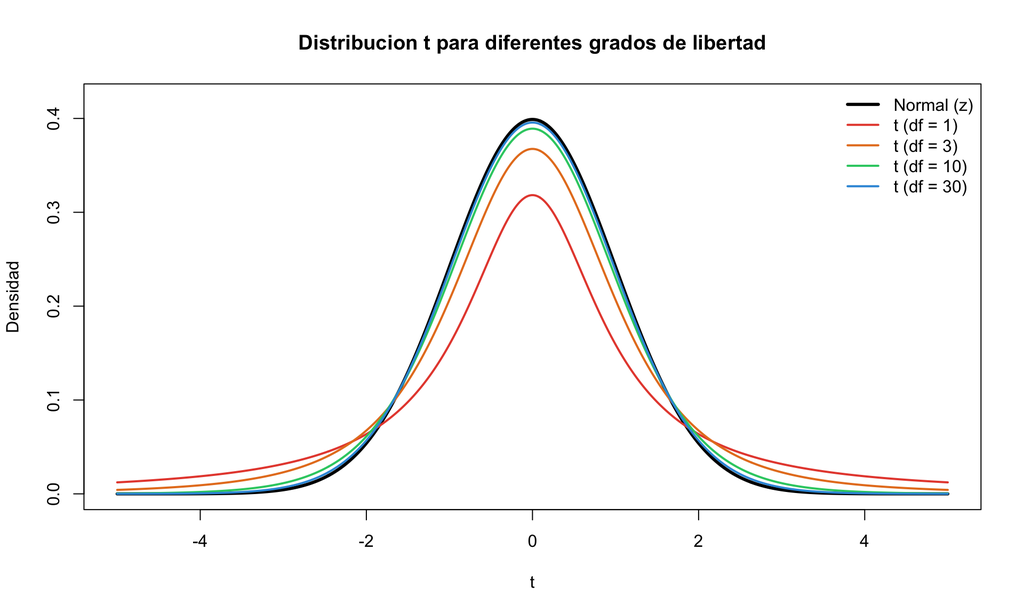

```r
# visualizar la distribución t para diferentes grados de libertad
x <- seq(-5, 5, length.out = 500)

plot(x, dnorm(x), type = "l", lwd = 3, col = "black",
     xlab = "t", ylab = "Densidad",
     main = "Distribucion t para diferentes grados de libertad",
     ylim = c(0, 0.42))

colors <- c("#E74C3C", "#E67E22", "#2ECC71", "#3498DB")
dfs <- c(1, 3, 10, 30)

for (i in seq_along(dfs)) {
  lines(x, dt(x, df = dfs[i]), col = colors[i], lwd = 2)
}

legend("topright",
       legend = c("Normal (z)", paste0("t (df = ", dfs, ")")),
       col = c("black", colors), lwd = c(3, rep(2, 4)),
       bty = "n")
```

**Tip**

Con **df > 30**, la distribución t es prácticamente idéntica a la normal. Por eso, con muestras grandes, el t-test y el z-test dan resultados casi iguales. Gosset trabajaba con n = 3-10 — ahí la diferencia importa mucho.

# El problema de Gosset: ¿es mejor esta cebada?

Imaginemos el tipo de problema que Gosset enfrentaba a diario en Guinness. Llegan dos lotes de cebada de proveedores diferentes y necesita saber si producen diferente **nivel de azúcar** (que la levadura convertirá en alcohol).

Con solo **5 muestras** de cada lote, ¿puede concluir algo?

Cada lote (= envío de cebada de un proveedor) se analiza tomando 5 muestras. Para cada muestra se mide el **nivel de azúcar (%)** — un porcentaje más alto significa mejor cebada para la cerveza.

```r
# nivel de azucar (%) de 5 muestras de cada lote de cebada
# lote = envio de cebada de un proveedor
set.seed(1908)  # el año del articulo de Student
lote_A <- round(rnorm(5, mean = 78, sd = 2.5), 1)
lote_B <- round(rnorm(5, mean = 81, sd = 2.5), 1)

print(paste("Lote A (% azucar):", paste(lote_A, collapse = ", ")))
```

```
[1] "Lote A (% azucar): 81.1, 79.4, 76.8, 75.3, 79.2"
```

```r
print(paste("Lote B (% azucar):", paste(lote_B, collapse = ", ")))
```

```
[1] "Lote B (% azucar): 77.8, 85.3, 79.9, 83.6, 79.6"
```

## Paso 1: formular las hipótesis

- **H<sub>0</sub>**: $\mu_A = \mu_B$ (ambos lotes producen el mismo nivel de azúcar)
- **H<sub>1</sub>**: $\mu_A \neq \mu_B$ (un lote es mejor que el otro)

**NotaNotación: $\mu$ vs $\bar{x}$**

$\mu$ (se pronuncia “mu”, del griego) es la **media poblacional** — el valor verdadero que no conocemos. $\bar{x}$ (“x barra”) es la **media muestral** — la que calculamos a partir de los datos. El objetivo del test es inferir algo sobre $\mu$ a partir de $\bar{x}$.

## Paso 2: explorar los datos

```r
# crear un tibble con los datos de ambos lotes
datos_cebada <- tibble(
  lote     = rep(c("Lote A", "Lote B"), each = 5),
  nivel_azucar = c(lote_A, lote_B)
)

# descriptivos por grupo usando tidyverse
datos_cebada |>
  group_by(lote) |>
  summarise(
    n     = n(),
    media = round(mean(nivel_azucar), 2),
    sd    = round(sd(nivel_azucar), 2)
  )
```

```
# A tibble: 2 x 4
  lote       n media    sd
  <chr>  <int> <dbl> <dbl>
1 Lote A     5  78.4   2.3
2 Lote B     5  81.2   3.1
```

```r
# guardar valores para los calculos a mano
n_A <- sum(datos_cebada$lote == "Lote A")
n_B <- sum(datos_cebada$lote == "Lote B")
m_A <- mean(lote_A)
m_B <- mean(lote_B)
sd_A <- sd(lote_A)
sd_B <- sd(lote_B)
print(paste("Diferencia de medias:", round(m_B - m_A, 2)))
```

```
[1] "Diferencia de medias: 2.88"
```

**Código**

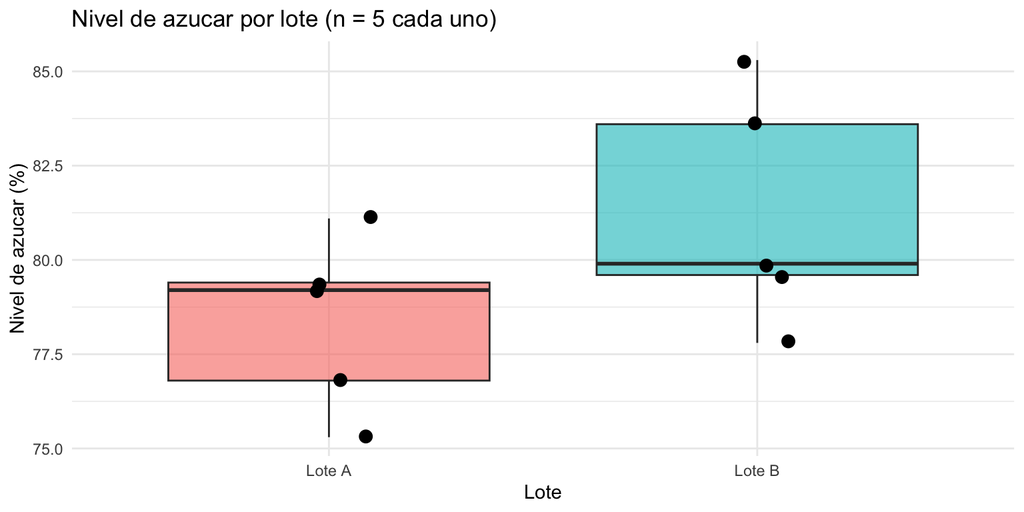

```r
# ggplot2: boxplot con puntos individuales
ggplot(datos_cebada, aes(x = lote, y = nivel_azucar, fill = lote)) +
  geom_boxplot(alpha = 0.6) +
  geom_jitter(width = 0.1, size = 3) +
  labs(x = "Lote", y = "Nivel de azucar (%)",
       title = "Nivel de azucar por lote (n = 5 cada uno)") +
  theme_minimal() +
  theme(legend.position = "none")
```

Hay una diferencia aparente, pero con solo 5 observaciones, ¿es real o es ruido?

## Paso 3: calcular el estadístico t

La fórmula del t de Student para muestras independientes:

$$t = \frac{\bar{x}_A - \bar{x}_B}{sd_{pooled} \times \sqrt{\frac{1}{n_A} + \frac{1}{n_B}}}$$

Donde:

- $\bar{x}_A$, $\bar{x}_B$ — medias muestrales de cada grupo (la barra indica “media”)
- $sd_{pooled}$ — desviación típica combinada (pooled SD)
- $n_A$, $n_B$ — número de observaciones en cada grupo
- El denominador completo ($sd_{pooled} \times \sqrt{1/n_A + 1/n_B}$) es el **error estándar de la diferencia** entre las medias

Y $sd_{pooled}$ se calcula como:

$$sd_{pooled} = \sqrt{\frac{(n_A - 1) \times sd_A^2 + (n_B - 1) \times sd_B^2}{n_A + n_B - 2}}$$

Donde:

- $sd_A$, $sd_B$ — desviaciones típicas de cada grupo
- $(n - 1)$ — ponderamos por los grados de libertad de cada grupo
- $n_A + n_B - 2$ — grados de libertad totales

```r
# pooled SD (desviacion tipica combinada)
sd_pooled <- sqrt(((n_A - 1) * sd_A^2 + (n_B - 1) * sd_B^2) / (n_A + n_B - 2))
print(paste("Pooled SD:", round(sd_pooled, 3)))
```

```
[1] "Pooled SD: 2.726"
```

```r
# error estandar de la diferencia
se_diff <- sd_pooled * sqrt(1/n_A + 1/n_B)
print(paste("SE diferencia:", round(se_diff, 3)))
```

```
[1] "SE diferencia: 1.724"
```

```r
# estadistico t
t_obs <- (m_A - m_B) / se_diff
df_obs <- n_A + n_B - 2
print(paste("t:", round(t_obs, 3)))
```

```
[1] "t: -1.67"
```

```r
print(paste("df:", df_obs))
```

```
[1] "df: 8"
```

```r
# pt() calcula la probabilidad acumulada de la distribucion t
# pt(abs(t_obs), lower.tail = FALSE) da la probabilidad de UNA cola
# como el test es bilateral (dos colas), multiplicamos por 2
# para incluir ambas colas (valores extremos positivos Y negativos)
p_valor <- 2 * pt(abs(t_obs), df = df_obs, lower.tail = FALSE)
print(paste("p-valor:", round(p_valor, 4)))
```

```
[1] "p-valor: 0.1334"
```

## Paso 4: visualizar en la distribución t

**Código**

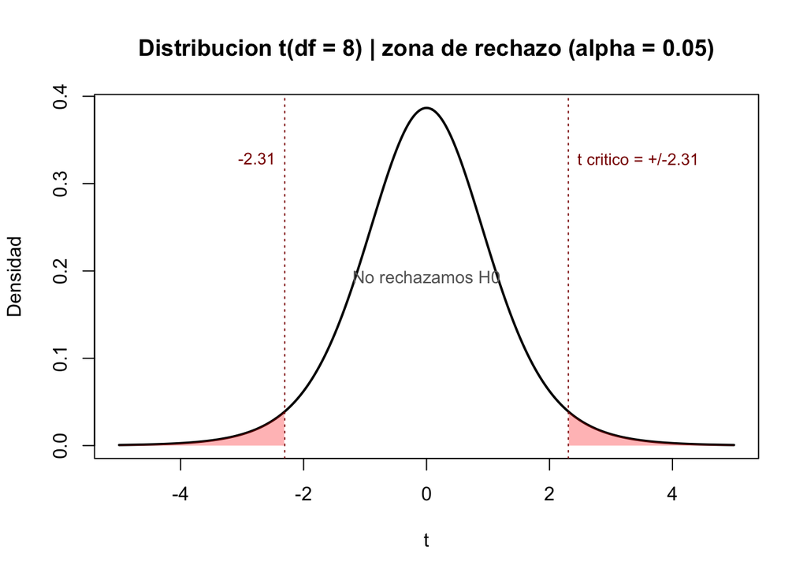

```r
# secuencia de valores para el eje x
x_seq <- seq(-5, 5, length.out = 500)
y_seq <- dt(x_seq, df = df_obs)

# qt() calcula el valor critico de t para alpha = 0.05 bilateral
# 0.975 porque repartimos el 5% entre las dos colas (2.5% cada una)
t_crit <- qt(0.975, df = df_obs)

# dibujar la curva t con df del ejemplo
plot(x_seq, y_seq, type = "l", lwd = 2,
     xlab = "t", ylab = "Densidad",
     main = paste0("Distribucion t(df = ", df_obs,
                   ") | zona de rechazo (alpha = 0.05)"))

# polygon() rellena las zonas de rechazo (colas) en rojo
idx_izq <- x_seq <= -t_crit
idx_der <- x_seq >=  t_crit
polygon(c(x_seq[idx_izq], rev(x_seq[idx_izq])),
        c(y_seq[idx_izq], rep(0, sum(idx_izq))),
        col = rgb(1, 0, 0, 0.3), border = NA)
polygon(c(x_seq[idx_der], rev(x_seq[idx_der])),
        c(y_seq[idx_der], rep(0, sum(idx_der))),
        col = rgb(1, 0, 0, 0.3), border = NA)

# lineas verticales de los valores criticos
abline(v = c(-t_crit, t_crit), col = "darkred", lwd = 1, lty = 3)
text( t_crit + 0.15, max(y_seq) * 0.85,
      paste0("t critico = +/-", round(t_crit, 2)),
      col = "darkred", cex = 0.85, adj = 0)
text(-t_crit - 0.15, max(y_seq) * 0.85,
      paste0("-", round(t_crit, 2)),
      col = "darkred", cex = 0.85, adj = 1)

# etiqueta de la region de no rechazo
text(0, max(y_seq) * 0.5, "No rechazamos H0", cex = 0.9, col = "gray40")
```

**Nota**

Las zonas rojas son las **zonas de rechazo**: si el t observado cae ahí, p < 0.05 y rechazamos H<sub>0</sub>. Si cae en la zona central, no rechazamos H<sub>0</sub>.

En nuestro ejemplo, t = -1.67 y p = 0.1334. Con df = 8 (solo 10 observaciones), las colas son anchas — necesitamos evidencia más fuerte para rechazar H<sub>0</sub> que con muestras grandes.

## Paso 5: verificar con R

```r
# Student's t (varianzas iguales — el test original de Gosset)
# guardamos el resultado en un objeto para poder usarlo con report()
# x = primer grupo, y = segundo grupo
# var.equal = TRUE para el t-test clasico de Student
resultado_t <- t.test(x = lote_A, y = lote_B, var.equal = TRUE)
resultado_t
```

```
    Two Sample t-test

data:  lote_A and lote_B
t = -1.6702, df = 8, p-value = 0.1334
alternative hypothesis: true difference in means is not equal to 0
95 percent confidence interval:
 -6.856236  1.096236
sample estimates:
mean of x mean of y
    78.36     81.24
```

**Tip**

Nuestros cálculos a mano coinciden exactamente con `t.test()`.

## Nota: Welch’s t-test

R usa por defecto el **t-test de Welch** (`var.equal = FALSE`), que es más robusto porque no asume varianzas iguales entre los dos grupos:

```r
# Welch's t (por defecto en R — var.equal = FALSE)
t.test(x = lote_A, y = lote_B)
```

```
    Welch Two Sample t-test

data:  lote_A and lote_B
t = -1.6702, df = 7.377, p-value = 0.1366
alternative hypothesis: true difference in means is not equal to 0
95 percent confidence interval:
 -6.915448  1.155448
sample estimates:
mean of x mean of y
    78.36     81.24
```

En la práctica, se recomienda siempre usar Welch. El t-test clásico de Student es un caso particular cuando las varianzas son iguales.

# Tamaño del efecto: Cohen’s d

El **p-valor** nos dice si la diferencia es estadísticamente significativa, pero no si es **grande o importante**. Para eso usamos el tamaño del efecto.

## Fórmula

$$d = \frac{\bar{x}_A - \bar{x}_B}{sd_{pooled}}$$

Donde:

- $\bar{x}_A - \bar{x}_B$ — la diferencia entre las medias de los dos grupos
- $sd_{pooled}$ — la desviación típica combinada (la misma que calculamos antes)

Es decir: la diferencia de medias expresada en **unidades de desviación típica**. Un d = 1 significa que los grupos difieren en 1 desviación típica.

## Interpretación (Cohen, 1988)

| d | Interpretación |
| --- | --- |
| 0.2 | Efecto pequeño |
| 0.5 | Efecto mediano |
| 0.8 | Efecto grande |

## Cálculo a mano

```r
# Cohen's d: diferencia de medias / pooled SD
d_manual <- (m_B - m_A) / sd_pooled
print(paste("Cohen's d =", round(d_manual, 3)))
```

```
[1] "Cohen's d = 1.056"
```

## Verificar con `effectsize::cohens_d()`

```r
library(effectsize)
cohens_d(x = lote_B, y = lote_A)
```

```
Cohen's d |        95% CI
-------------------------
1.06      | [-0.31, 2.37]

- Estimated using pooled SD.
```

**Tip**

Un d de 1.06 indica un efecto grande. Incluso con muestras pequeñas, el tamaño del efecto nos ayuda a interpretar la relevancia práctica del resultado.

# Interpretación en formato APA

```r
# report::report() genera un parrafo de resultados listo para copiar en un articulo
library(report)
report(x = resultado_t)
```

```
Effect sizes were labelled following Cohen's (1988) recommendations.

The Two Sample t-test testing the difference between lote_A and lote_B (mean of x = 78.36, mean of y = 81.24) suggests
that the effect is negative, statistically not significant, and large (difference = -2.88, 95% CI [-6.86, 1.10], t(8) =
-1.67, p = 0.133; Cohen's d = -1.06, 95% CI [-2.37, 0.31])
```

**Tip**

`report::report()` genera automáticamente un párrafo de resultados en formato APA — con t, df, p y tamaño del efecto. Ideal para copiar directamente en el artículo.